# metodes

Nama : Dohan Rizqi Hadityo | NIM : 210411100195 | Kelas : Metode Statistika D

## Exponential Smoothing (Pemulusan Exponensial)

Metode exponential smoothing merupakan metode peramalan yang cukup baik untuk peramalan jangka panjang dan jangka menengah, terutama pada tingkat operasional suatu perusahaan, dalam perkembangan dasar matematis dari metode smoothing (forcasting by Makridakis, hal 79-115) dapat dilihat bahwa konsep exponential telah berkembang dan menjadi metode praktis dengan penggunaan yang cukup luas, terutama dalam peramalan bagi persediaan.

Kelebihan utama dari metode exponential smoothing adalah dilihat dari kemudahan dalam operasi yang relative rendah, ada sedikit keraguan apakah ketepatan yang lebih baik selalu dapat dicapai dengan menggunakan (QS) Quantitatif sistem ataukah metode dekonposisi yang secara intuitif menarik, namun dalam hal ini jika diperlukan peramalan untuk ratusan item.

Menurut Makridakis, Wheelwright & Mcgee dalam bukunya “forcasting” (hal 104). Menyatakan bahwa apabila data yang dianalisa bersifat stationer, maka penggunaan metode rata-rata bergerak (moving average) atau single exponential smoothing cukup tepat akan tetapi apabila datanya menunjukan suatu trend linier, maka model yang baik untuk digunakan adalah exponential smoothing linier dari brown atau model exponential smoothing linier dari holt.

#### Cara Menghitung Exponential Smoothing

Peramalan dengan Exponential Smoothing atau Metode Penghalusan Eksponensial ini cukup mudah, yaitu dengan memasukan prakiraan permintaan sekarang dengan data permintaan nyata atau data permintaan aktual ke dalam rumus Exponential Smoothing.

#### Rumus Exponential Smoothing (Penghalusan Eksponensial)

##### Ft = Ft – 1 + α (Dt-1 – Ft-1)

Dimana :

Ft = Prakiraan Permintaan sekarang Ft-1 = Prakiraan Permintaan yang lalu α = Konstanta Eksponensial Dt-1 = Permintaan Nyata

#### Contoh Kasus Exponential Smoothing

Dohan adalah penjual ikan cupang dan ia menjualnya secara online maupun offline dengan menggunakan live di sosial media, baik youtube, instagram, maupun tiktok. Data penjualan ikan cupang pada bulan Januari adalah 143 ekor, bulan Februari 135 ekor, bulan Maret 152 ekor, bulan April 144 ekor, bulan Mei 120 ekor, bulan Juni 132 ekor, bulan Juli 122 ekor, bulan Agustus 163 ekor, bulan September 174 ekor, bulan Oktober 159 ekor, bulan November 145 ekor,dan bulan Desember 124 ekor. Kemudian Dohan memperkirakan berapa perkiraan ikan cupang yang dijual pada bulan Januari 2022? Maka dilakukan perhitungan dengan metode peramalan Penghalusan Exponential (exponential smoothing).

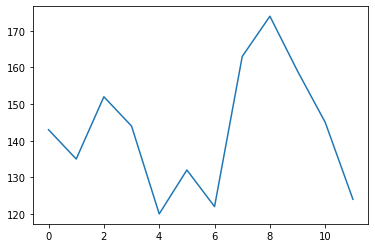

```python
#bentuk diagram yang akan dibuat dari data diatas adalah

import matplotlib.pyplot as mpl
mpl.plot([143,135,152,144,120,132,122,163,174,159,145,124])
```

#### Jawab :

Langkah ke 2 yakni menghitung nilai peramalan periode pertama, cara menghitungnya yakni dengan menjumlahkan keseluruhan data permintaan kemudian dibagi dengan banyaknya periode yang ada, dimana total keseluruhan permintaan adalah 1713 dibagi banyaknya periode sebanyak 12 periode sehingga, F (1) = 1713/12 = 142.75

Langkah ke 3 yakni menghitung nilai peramalan di keseluruhan periode.

F2= 142,75 + 0,2 x (143 - 142,75) = 142,80

F3 = 142,80 + 0,2 x (135 – 142,80) = 141,24

F4 = 141,24 + 0,2 x (152 – 141,24) = 143,39

F7 = 138,80 + 0,2 x (132 – 138,80) = 137,44

F8 = 137,44 + 0,2 x (122 – 137,44) = 134,35

F9 = 134,35 + 0,2 x (163 – 134,35) = 140,08

F10 = 140,08 + 0,2 x (174 – 140,08) = 146,86

F11 = 146,86 + 0,2 x (159 – 146,86) = 149,29

F12 = 149,29 + 0,2 x (145 – 149,29) = 148,43

F13 = 148,43 + 0,2 x (124 – 148,43) = 143,54

Sehingga dari hasil permalan menggunakan exponential smoothing diperoleh hasil bahwa perkiraan permintaan penjualan ikan cupang pada bulan Januari 2022 sejumlah 143,54 ekor ikan cupang atau dibulatkan menjadi 144 ekor ikan cupang

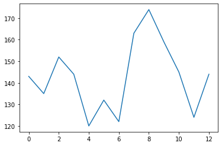

```python
#diagram yang dibentuk dari data diatas adalah sebagai berikut

import matplotlib.pyplot as mpl
mpl.plot([143,135,152,144,120,132,122,163,174,159,145,124,144])
```

## Moving Average

Rata-rata bergerak (moving averages) diperoleh melalui penjumlahan dan pencarian nilai rata-rata dari sejumlah periode tertentu, setiap kali meghilangkan nilai terlama dan menambah nilai baru (Subagyo, 1986

#### Cara Menghitung Moving Avarage :

1. Mengidentifikasi pola historis dari data aktual permintaan
2. Memilih model peramalan yang sesuai dengan pola historis dari data aktual permintaan
3. Melakukan analisis data berdasarkan model peramalan yang dipilih
4. Memilih model peramalan yang tepat berdasarkan MAD (Mean Absolut Deviation) terkecil
5. Memeriksa keandalan model peramalan berdasarkan peta kontrol tracking signal

#### Rumus Moving Avarage:

##### MA = ΣX / Jumlah Periode

Keterangan : MA = Moving Average ΣX = Keseluruhan Penjumlahan dari semua data periode waktu yang diperhitungkan Jumlah Periode = Jumlah Periode Rata-rata bergerak

atau dapat ditulis dengan :

##### MA = (n1 + n2 + n3 + …) / n

Keterangan : MA = Moving Average n1 = data periode pertama n2 = data periode kedua n3 = data periode ketiga dan seterusnya n = Jumlah Periode Rata-rata bergerak

#### Contoh Kasus Moving Average

Ilham mempunyai usaha di bidang material bangunan, Ilham ingin memperkirakan (forecasting) berapa material bangunan yang bisa Ilham jual di bulan Januari 2022. Dengan data penjualan material bangunan selama tahun 2021 sebagai berikut Januari 63 material, bulan Februari 71 material, bulan Maret 88 material, bulan April 68 material, bulan Mei 74 material, bulan Juni 91 material, bulan Juli 103 material, bulan Agustus 112 material, bulan September 84 meterial, bulan Oktober 99 material, bulan November 147 material, bulan Desember 151 material. Maka dilakukan perhitungan dengan metode perkiraan Moving Average.

```python
#maka dari kasus diatas, lakukan perhitungan dengan menjumlahkan data penjualan 12 periode kemudian dibagi 12
print((63+71+88+68+74+91+103+112+84+99+147+151)/12)
```

```
95.91666666666667
```

Maka perkiraan penjualan material bangunan pada bulan Januari 2022 adalah sebanyak 96 material

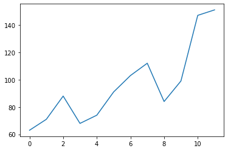

```python
#diagram penjualan material bangunan pada tahun 2021

import matplotlib.pyplot as mpl
mpl.plot([63,71,88,68,74,91,103,112,84,99,147,151])
```

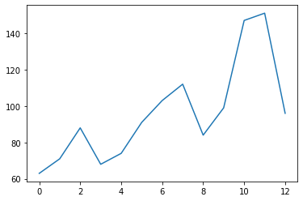

```python
#dibawah ini adalah diagram penjualan material bangunan pada bulan januari 2022

import matplotlib.pyplot as mpl
mpl.plot([63,71,88,68,74,91,103,112,84,99,147,151,96])
```